# Nivel de bienestar personal de los alumnos de UTEC en épocas de pandemia (2020 a la actualidad)

14 Diciembre, 2021

## Bienestar Estudiantil en UTEC

Integrantes:

- Anshel Chuquiviguel Zaña (Líder) 100%
- Sergio Luis Fierro Neyra 100%
- Jean Dante Claudio Gomez Urquiza 100%

### Introducción:

#### Descripción del tema:

Actualmente, por la pandemia del COVID 19 la salud mental y el bienestar personal están muy deteriorados y más aún en estudiantes universitarios debido a la carga académica a la que están sometidos. No obstante, esta problemática ha pasado a un segundo plano debido a la crisis sanitaria que vivimos, y por ello decidimos realizar este trabajo, el cual se enfoca esencialmente en el ámbito psicológico de los estudiantes universitarios de UTEC.

El trabajo busca informar sobre la situación psicológica actual de los estudiantes y su efecto en su situación académica. Para ello se está evaluando variables como sus hábitos, sus metas, su rendimiento académico, su estado de salud, su economía y sus problemas familiares. Además, cabe recalcar que los datos se recolectarán mediante encuestas, el cual se realizará hacia el 200 estudiantes y así podremos recopilar información acerca de su bienestar personal.

### Objetivos:

#### Pregunta de investigación:

**¿Cuál es el nivel de bienestar personal de los alumnos de UTEC en épocas de pandemia (2020 a la actualidad)?**

#### Objetivos de la investigación:

*- Identificar si el IMC promedio de los estudiantes de UTEC es óptimo.*

*- Conocer el bienestar de salud y académico de los alumnos de UTEC en épocas de pandemia.*

*- Analizar las causas más comunes por las cuales los estudiantes presentan un bajo bienestar personal.*

*- Conocer las dificultades en su rendimiento académico.*

### Marco Teórico

#### Variables y preguntas:

##### **Área personal: 8 variables**

| Pregunta | Variable | Tipo de variable | Restricciones |
| --- | --- | --- | --- |
| Nombres y Apellidos | Nombres completos | Categórica nominal | Alumno UTEC |
| Género | Género | Categórica nominal | Masculino o Femenino |
| Carrera a la cual pertenece | Carrera | Categórica nominal | Las carreras de UTEC |
| Ciclo el cual cursa | Ciclo | Numérica discreta | Número entero positivo |
| ¿Qué tan satisfecho se encuentra con las clases en línea? | Satisfacción con las clases en línea | Categórica ordinal | Del 1 al 5 |
| ¿Cuenta con alguno de estos recursos tecnológicos? Puede seleccionar más de una opción. | Disponibilidad recursos tecnológicos | Categórica nominal | Internet/Laptop o PC/Teléfono inteligente/Impresora/Tablet o Ipad/Ninguno |
| ¿Cuánto es el ingreso promedio familiar en su hogar? | Ingreso promedio de dinero mensual a la familia | Numérica discreta | Número entero positivo |
| ¿Estudia y trabaja? | Estudia y trabaja | Categórica nominal | Si o no. |

##### **Área académica: 7 variables**

| Pregunta | Variable | Tipo de variable | Restricciones |
| --- | --- | --- | --- |
| ¿Cuál fue su promedio de notas el ciclo anterior? | Promedio de notas | Numérica continua | Número positivo, menor que 20. |
| ¿Qué tan satisfecho se encuentra con sus resultados académicos? | Satisfacción con sus notas | Categórica ordinal | Del 1 al 5 |
| ¿Cuántas horas dedica a sus estudios? | Horas dedicadas al estudio | Numérica discreta | Número entero positivo menor a 24 |
| ¿Cuántas horas dispone para su distracción? | Horas dedicadas al ocio | Numérica discreta | Número entero positivo menor a 24 |
| ¿Cuántos cursos desaprobó el ciclo anterior? | Cantidad de cursos desaprobados | Numérica discreta | Número entero positivo |
| Desde su inicio en la universidad, ¿en cuántos cursos se matriculó por tercera vez? | Cursos llevados por tercera vez | Numérica discreta | Número entero positivo |
| ¿Qué tan satisfecho se encuentra con la elección de su carrera? | Satisfacción con la carrera | Categórica ordinal | Del 1 al 5 |

##### **Área de salud: 6 variables**

| Pregunta | Variable | Tipo de variable | Restricciones |
| --- | --- | --- | --- |
| Indique su talla | Talla | Numérica continua | Número positivo |
| Indique su peso | Peso | Numérica continua | Número positivo |
| ¿Cuántas horas duerme? | Horas que duerme | Numérica discreta | Número entero positivo |
| ¿Cuántas horas a la semana realiza actividad física? | Horas a la semana que hace ejercicio | Numérica discreta | Número entero positivo |
| ¿Qué tan balanceada cree que es su alimentación? | Alimentación balanceada | Categórica ordinal | Del 1 al 5 |
| ¿Padece de algún tipo de enfermedad? | Enfermedad que posee | Categórica nominal | Si o no. Sí sí, detallar |

#### Planificación

**Población: Estudiantes de UTEC**

**Tamaño de muestra: al rededor de 200 estudiantes**

**Los niveles de confianza en todos los descriptores numéricos y pruebas de hipótesis son del 95% del (promedio, varianza)**

#### Mostramos los datos

```r
DF
```

| Nombres y Apellidos | Genero | Carrera | Ciclo | Talla | Peso | HorasZZZ | HorasFisica | AlimentacionBalance | Enfermedad | PromedioAnterior | SatisfaccionResultados | HorasEstudio | HorasDistraccion | CursosDesaprobados | CursosMatric3era | SatisfaccionCarrera | RecursosTecnologicos | IngresoPromedioFamiliar | EstudiarTrabajar | SatisfaccionClases | QueEnfermedad | Edad |
| --- | --- | --- | --- | --- | --- | --- | --- | --- | --- | --- | --- | --- | --- | --- | --- | --- | --- | --- | --- | --- | --- | --- |
| Anshel Chuquiviguel | Masculino | Ingeniería Civil | 3 | 160 | 48.0 | 6 | 1 | 3 | No | 17.27 | 3 | 10 | 1 | 0 | 0 | 3 | Internet, Laptop o PC, Teléfono, Impresora | 1600 | No | 3 | NA | 18 |
| Rodrigo Martin Ramirez Malpaso | Masculino | Ingeniería Civil | 4 | 170 | 72.0 | 6 | 8 | 4 | No | 14.00 | 3 | 10 | 2 | 0 | 0 | 5 | Internet, Laptop o PC, Teléfono, Impresora | 5000 | No | 3 | NA | 19 |
| Christian Chuquimantari Arteaga | Masculino | Ingeniería Mecatrónica | 3 | 165 | 63.0 | 4 | 1 | 4 | Sí | 14.56 | 1 | 5 | 10 | 0 | 0 | 3 | Internet, Laptop o PC, Teléfono | 1000 | No | 3 | Gastritis | 18 |
| Pablo Achic Maldonado | Masculino | Ingeniería Mecánica | 3 | 168 | 56.0 | 4 | 1 | 4 | No | 13.00 | 4 | 12 | 4 | 1 | 0 | 5 | Internet, Laptop o PC, Teléfono | 950 | No | 5 | NA | 20 |
| Paolo Sebastian Armas Vega | Masculino | Ciencia de la Computación | 4 | 180 | 70.0 | 6 | 1 | 3 | No | 15.32 | 3 | 6 | 2 | 0 | 0 | 4 | Internet, Laptop o PC, Teléfono, Impresora | 1200 | No | 3 | NA | 18 |
| Yamin rony barzola quispe | Masculino | Ingeniería Electrónica | 3 | 161 | 63.0 | 8 | 5 | 3 | No | 12.00 | 1 | 2 | 2 | 3 | 4 | 4 | Internet, Laptop o PC, Teléfono | 1000 | Sí | 2 | NA | 21 |
| Lino Anderson Mauricio Rimachi | Masculino | Ingeniería Mecatrónica | 3 | 173 | 70.0 | 7 | 4 | 2 | No | 13.00 | 2 | 3 | 3 | 2 | 0 | 4 | Internet, Laptop o PC, Teléfono | 800 | No | 4 | NA | 19 |
| Carlitos Brayan Mora Montero | Masculino | Ingeniería Civil | 3 | 160 | 50.0 | 7 | 2 | 4 | No | 17.01 | 4 | 2 | 1 | 0 | 0 | 5 | Internet, Laptop o PC, Teléfono, Impresora | 1000 | No | 4 | NA | 18 |
| Emerson Chiquillan Amorin | Masculino | Ingeniería Civil | 3 | 171 | 72.0 | 7 | 6 | 3 | No | 11.00 | 2 | 8 | 1 | 3 | 1 | 5 | Internet, Laptop o PC, Teléfono | 3000 | No | 3 | NA | 21 |
| Diana Sherlin Vargas Pastor | Femenino | Ingeniería Civil | 3 | 150 | 53.0 | 5 | 8 | 3 | No | 15.59 | 3 | 8 | 2 | 0 | 0 | 4 | Internet, Laptop o PC, Teléfono, Impresora | 3500 | Sí | 4 | NA | 18 |

[output cut: 191 more lines]

#### Funciones

##### Función de redondeo a 2 decimales

```r
r <- function(x){
  return(round(x,2))
}
```

##### Función de descriptores numéricos

```r
descpNumericos<-function(datosD,alfa=0.05){
  media_=r(mean(datosD))
  mediana_=r(median(datosD))
  desEst_=r(sd(datosD))
  var_=r(desEst_^2)

  m1<-r( media_ - (qt(1-alfa/2,length(datosD)-1)*(desEst_/sqrt(length(datosD)))))
  m2<-r( media_ + (qt(1-alfa/2,length(datosD)-1)*(desEst_/sqrt(length(datosD)))))

  v1 <- r(((length(datosD)-1)*(desEst_^2))/qchisq(1-alfa/2,(length(datosD)-1)))
  v2 <- r(((length(datosD)-1)*(desEst_^2))/qchisq(alfa/2,(length(datosD)-1)))

  d1 <- r(sqrt(((length(datosD)-1)*(desEst_^2))/qchisq(1-alfa/2,(length(datosD)-1))))
  d2 <- r(sqrt(((length(datosD)-1)*(desEst_^2))/qchisq(alfa/2,(length(datosD)-1))))


  print(paste("Promedio: ",media_))
  print(paste("Intervalo de confianza del promedio: [ ",m1," : ",m2," ]"))

  print(paste("desviación estandar: ",desEst_))
  print(paste("Intervalo de confianza de la desviación estandar: [ ",d1," : ",d2," ]"))

  print(paste("Varianza: ",var_))
  print(paste("Intervalo de confianza de la varianza: [ ",v1," : ",v2," ]"))

  print(paste("Mediana: ",mediana_))

  summary(datosD)


}
```

## Descripción de variables e intervalos de confianza

### Variables referenciales

**Las siguientes variables cumplen un papel descriptivo en el trabajo**

#### Género

##### Tabla de género

```r
tablaGenero<-DF %>% count(Genero)
tablaGenero<-tablaGenero %>% mutate(fr=round(n/(length(DF$`Nombres y Apellidos`)),4))
tablaGenero<-tablaGenero%>% mutate(fp=100*tablaGenero$fr)
tablaGenero
```

| Genero | n | fr | fp |
| --- | --- | --- | --- |
| Femenino | 64 | 0.3184 | 31.84 |
| Masculino | 137 | 0.6816 | 68.16 |

##### Gráfico circular de género

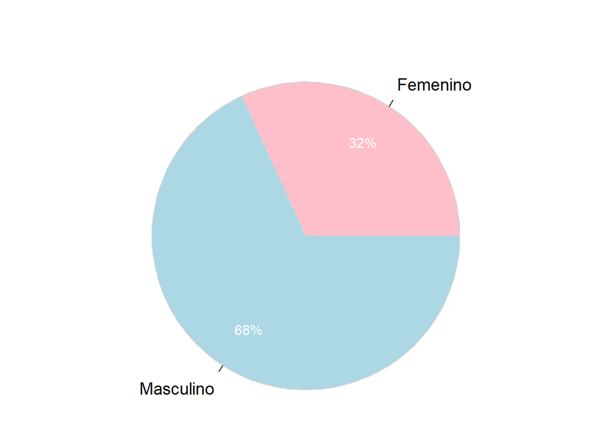

```
## >>> Suggestions
## PieChart(X.DF.Genero., hole=0)  # traditional pie chart
## PieChart(X.DF.Genero., values="%")  # display %'s on the chart
## BarChart(X.DF.Genero.)  # bar chart
## Plot(X.DF.Genero.)  # bubble plot
## Plot(X.DF.Genero., values="count")  # lollipop plot
##
##
## --- X.DF.Genero. ---
##
##
##                Femenino  Masculino     Total
## Frequencies:         64        137       201
## Proportions:      0.318      0.682     1.000
##
##
## Chi-squared test of null hypothesis of equal probabilities
##   Chisq = 26.512, df = 1, p-value = 0.000
```

```r
tab2.genero<-data.frame((DF$Genero))

PieChart(X.DF.Genero., hole = 0, values = "%", data = tab2.genero,
         fill = c("pink","lightblue"), main = "")
```

#### Carrera

##### Tabla de carreras

```r
tablaCarreras<-DF %>% count(Carrera)
tablaCarreras<-tablaCarreras %>% mutate(fr=round(n/(length(DF$`Nombres y Apellidos`)),4))
tablaCarreras<-tablaCarreras %>% mutate(fp=100*tablaCarreras$fr)
tablaCarreras<-tablaCarreras %>% arrange(desc(n))
tablaCarreras
```

| Carrera | n | fr | fp |
| --- | --- | --- | --- |
| Ingeniería Civil | 54 | 0.2687 | 26.87 |
| Bioingeniería | 36 | 0.1791 | 17.91 |
| Ingeniería Mecatrónica | 25 | 0.1244 | 12.44 |
| Ciencia de la Computación | 19 | 0.0945 | 9.45 |
| Ingeniería Industrial | 18 | 0.0896 | 8.96 |
| Ingeniería Ambiental | 13 | 0.0647 | 6.47 |
| Ingeniería de la Energía | 13 | 0.0647 | 6.47 |
| Ingeniería Mecánica | 12 | 0.0597 | 5.97 |
| Ingeniería Electrónica | 9 | 0.0448 | 4.48 |
| Ingeniería Química | 2 | 0.0100 | 1.00 |

##### Gráfico de barras para carreras

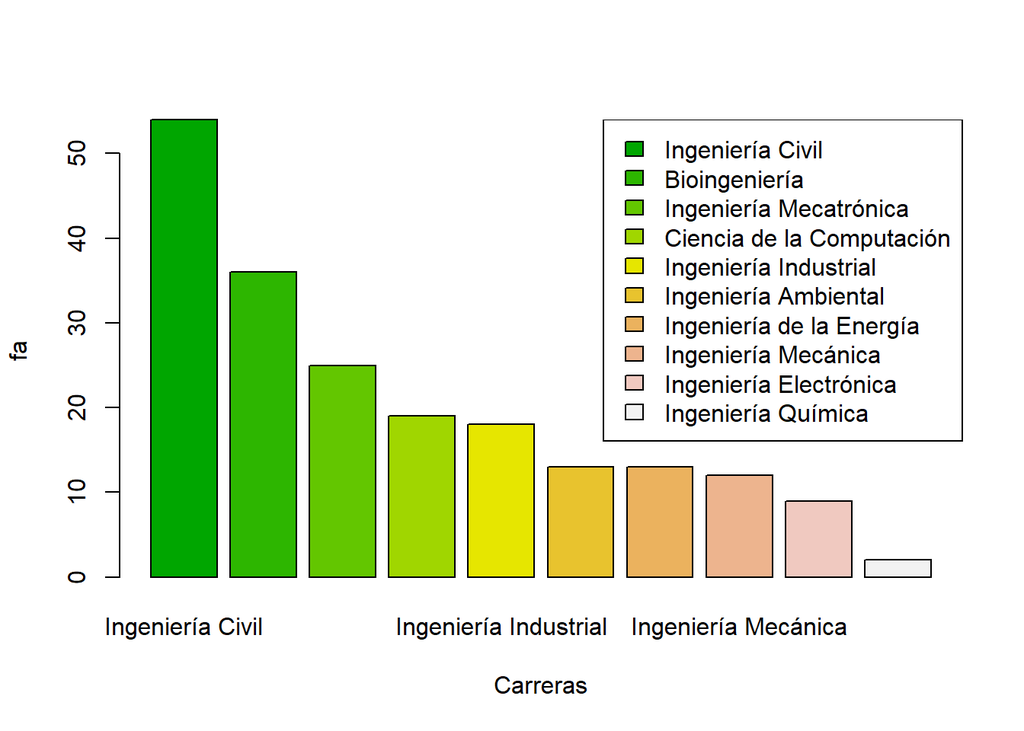

```r
tab.carreras<-table(DF$Carrera)

barplot(tab.carreras[order(tab.carreras, decreasing = TRUE)], col=terrain.colors(10),xlab="Carreras", ylab="fa")
#barplot(df3[1:5,2], col=terrain.colors(5),xlab="Número de hijos", ylab="fr") #columnas
legend("topright", legend = rownames(tab.carreras[order(tab.carreras, decreasing = TRUE)])[1:10], fill = terrain.colors(10))
```

#### Ciclo

##### Tabla de ciclos

```r
tablaCiclos<-DF %>% count(Ciclo)
tablaCiclos<-tablaCiclos %>% mutate(fr=round(n/(length(DF$`Nombres y Apellidos`)),4))
tablaCiclos<-tablaCiclos %>% mutate(fp=tablaCiclos$fr)
tablaCiclos
```

| Ciclo | n | fr | fp |
| --- | --- | --- | --- |
| 1 | 7 | 0.0348 | 0.0348 |
| 2 | 21 | 0.1045 | 0.1045 |
| 3 | 87 | 0.4328 | 0.4328 |
| 4 | 47 | 0.2338 | 0.2338 |
| 5 | 17 | 0.0846 | 0.0846 |
| 6 | 13 | 0.0647 | 0.0647 |
| 7 | 6 | 0.0299 | 0.0299 |
| 8 | 3 | 0.0149 | 0.0149 |

##### Descriptores numéricos de ciclos

```r
tablaCiclos[which.max(tablaCiclos$n),]
```

| Ciclo | n | fr | fp |
| --- | --- | --- | --- |
| 3 | 87 | 0.4328 | 0.4328 |

```r
print(paste("Los estudiantes que más han realizado la encuesta son del ciclo: ",tablaCiclos[which.max(tablaCiclos$n),1]))
```

```
## [1] "Los estudiantes que más han realizado la encuesta son del ciclo:  3"
```

```r
summary(DF$Ciclo)
```

```
##    Min. 1st Qu.  Median    Mean 3rd Qu.    Max.
##   1.000   3.000   3.000   3.617   4.000   8.000
```

##### Gráfico de barras para ciclos

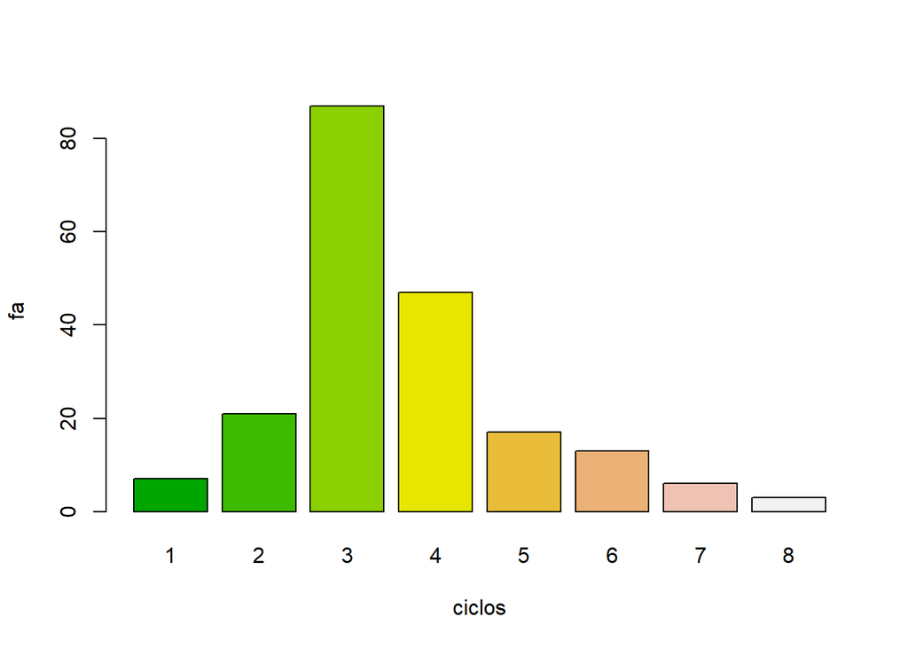

```r
tab.ciclos<-table(DF$Ciclo)
barplot(tab.ciclos,col=terrain.colors(8),xlab="ciclos", ylab="fa")
```

#### Edad

##### Tabla de edades

```r
tablaEdades<-DF %>% count(Edad)
tablaEdades<-tablaEdades %>% mutate(fr=round(n/(length(DF$`Nombres y Apellidos`)),4))
tablaEdades<-tablaEdades %>% mutate(fp=fr*100)
tablaEdades
```

| Edad | n | fr | fp |
| --- | --- | --- | --- |
| 17 | 15 | 0.0746 | 7.46 |
| 18 | 68 | 0.3383 | 33.83 |
| 19 | 51 | 0.2537 | 25.37 |
| 20 | 37 | 0.1841 | 18.41 |
| 21 | 16 | 0.0796 | 7.96 |
| 22 | 8 | 0.0398 | 3.98 |
| 23 | 4 | 0.0199 | 1.99 |
| 24 | 2 | 0.0100 | 1.00 |

#### Gráfico de barras de edades

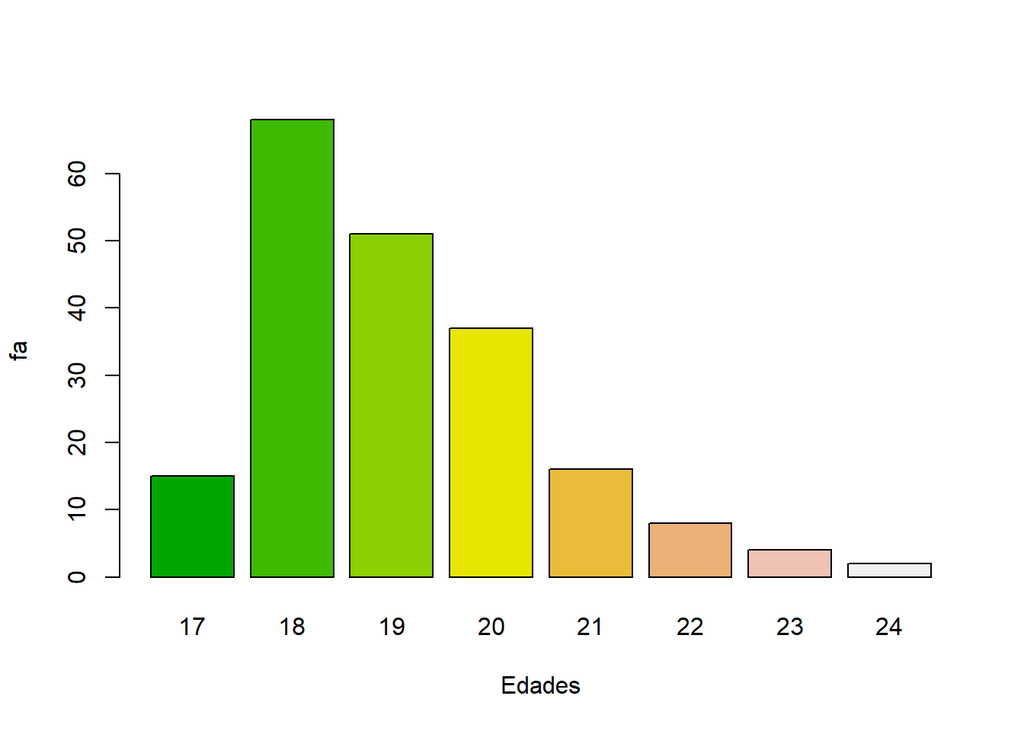

```r
tab.Edades<-table(DF$Edad)
gb<-barplot(tab.Edades,col=terrain.colors(8),xlab="Edades", ylab="fa")
```

### Variables de salud

#### Talla

##### Tabla de tallas

|  | fa | fr | fp |
| --- | --- | --- | --- |
| [143.62:148.38) | 1 | 0.00 | 0 |
| [148.38:153.12) | 9 | 0.04 | 4 |
| [153.12:157.88) | 14 | 0.07 | 7 |
| [157.88:162.62) | 28 | 0.14 | 14 |
| [162.62:167.38) | 38 | 0.19 | 19 |
| [167.38:172.12) | 54 | 0.27 | 27 |
| [172.12:176.88) | 33 | 0.16 | 16 |
| [176.88:181.62) | 23 | 0.11 | 11 |
| [181.62:186.38) | 1 | 0.00 | 0 |
| Total | 201 | 1.00 | 100 |

##### Descriptores numéricos de tallas

```r
descpNumericos(DF$Talla)
```

```
## [1] "Promedio:  167.54"
## [1] "Intervalo de confianza del promedio: [  166.46  :  168.62  ]"
## [1] "desviación estandar:  7.78"
## [1] "Intervalo de confianza de la desviación estandar: [  7.09  :  8.63  ]"
## [1] "Varianza:  60.53"
## [1] "Intervalo de confianza de la varianza: [  50.22  :  74.39  ]"
## [1] "Mediana:  169"
```

```
##    Min. 1st Qu.  Median    Mean 3rd Qu.    Max.
##   146.0   162.0   169.0   167.5   173.0   184.0
```

##### Gráfico de pox plot de tallas

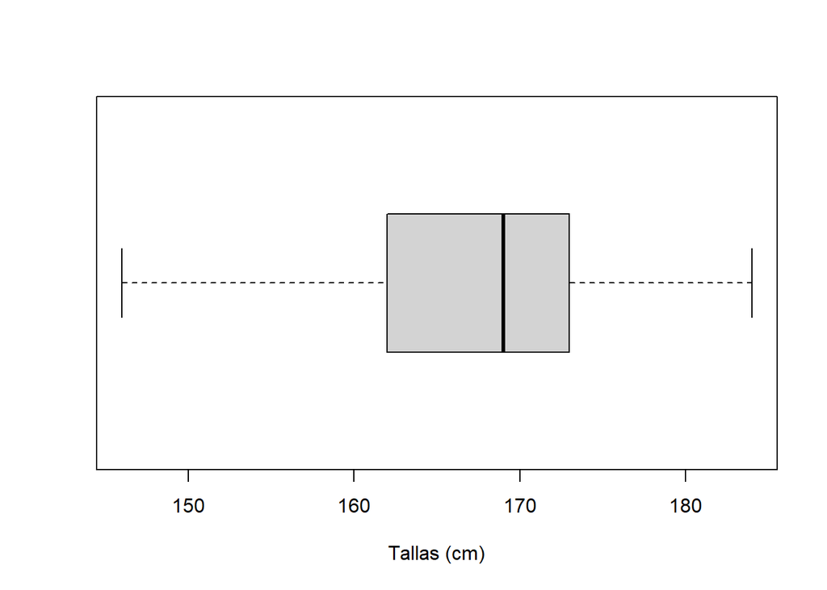

```r
boxplot(DF$Talla,horizontal = TRUE,xlab="Tallas (cm)")
```

##### Histograma de tallas

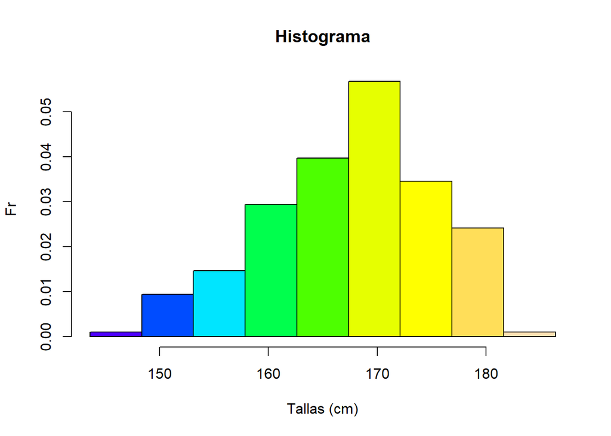

```r
hist(datosTallas,breaksTallas,freq=FALSE, ylab="Fr", xlab="Tallas (cm)", main="Histograma",col=topo.colors(Ktallas))
```

#### Pesos

##### Tabla de pesos

|  | fa | fr | fp |
| --- | --- | --- | --- |
| [37.44:44.56) | 3 | 0.01 | 1 |
| [44.56:51.69) | 15 | 0.07 | 7 |
| [51.69:58.81) | 32 | 0.16 | 16 |
| [58.81:65.94) | 54 | 0.27 | 27 |
| [65.94:73.06) | 50 | 0.25 | 25 |
| [73.06:80.19) | 29 | 0.14 | 14 |
| [80.19:87.31) | 11 | 0.05 | 5 |
| [87.31:94.44) | 5 | 0.02 | 2 |
| [94.44:101.56) | 2 | 0.01 | 1 |
| Total | 201 | 1.00 | 100 |

##### Descriptores numéricos de pesos

```r
descpNumericos(DF$Peso)
```

```
## [1] "Promedio:  65.85"
## [1] "Intervalo de confianza del promedio: [  64.31  :  67.39  ]"
## [1] "desviación estandar:  11.04"
## [1] "Intervalo de confianza de la desviación estandar: [  10.06  :  12.24  ]"
## [1] "Varianza:  121.88"
## [1] "Intervalo de confianza de la varianza: [  101.12  :  149.8  ]"
## [1] "Mediana:  65"
```

```
##    Min. 1st Qu.  Median    Mean 3rd Qu.    Max.
##   41.00   59.00   65.00   65.85   73.00   98.00
```

##### Gráfico de pox plot de pesos

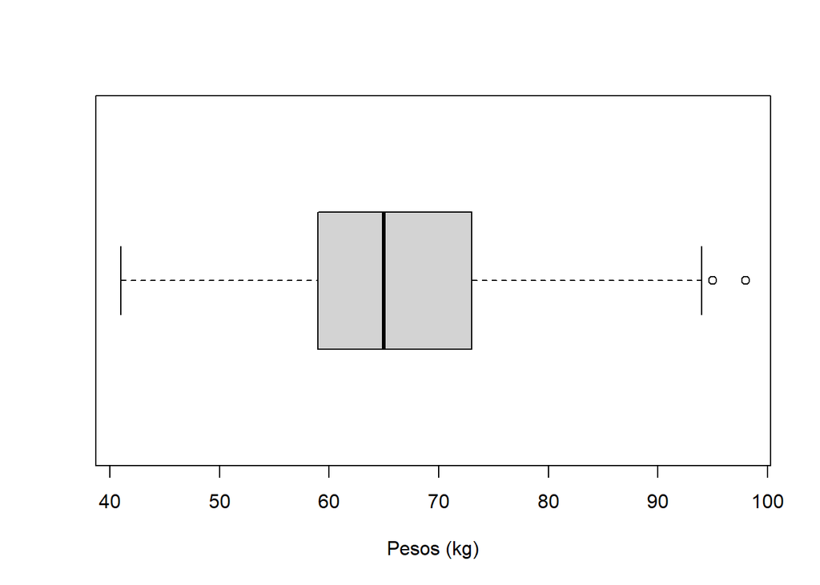

```r
boxplot(DF$Peso,horizontal = TRUE,xlab="Pesos (kg)")
```

##### Histograma de pesos

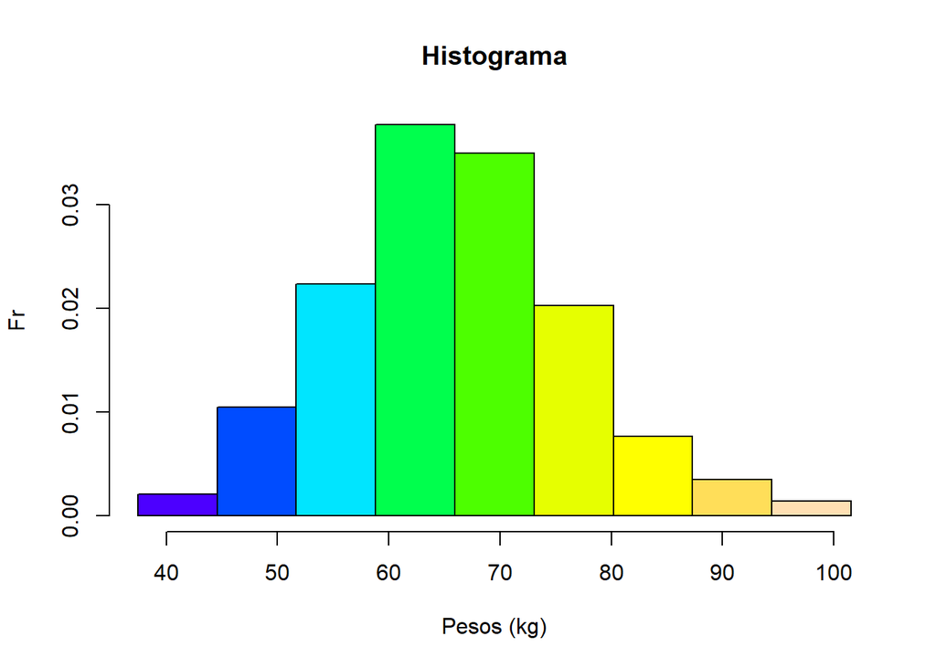

```r
hist(datosPesos,breaksPesos,freq=FALSE, ylab="Fr", xlab="Pesos (kg)", main="Histograma",col=topo.colors(KPesos))
```

#### IMC

##### Datos IMC

$IMC = \frac{Peso(kg)}{altura(m)^2}()$

```r
DF2<-DF %>% mutate(IMC=Peso/((Talla/100)*(Talla/100)))
DF2
```

| Nombres y Apellidos | Genero | Carrera | Ciclo | Talla | Peso | HorasZZZ | HorasFisica | AlimentacionBalance | Enfermedad | PromedioAnterior | SatisfaccionResultados | HorasEstudio | HorasDistraccion | CursosDesaprobados | CursosMatric3era | SatisfaccionCarrera | RecursosTecnologicos | IngresoPromedioFamiliar | EstudiarTrabajar | SatisfaccionClases | QueEnfermedad | Edad | IMC |
| --- | --- | --- | --- | --- | --- | --- | --- | --- | --- | --- | --- | --- | --- | --- | --- | --- | --- | --- | --- | --- | --- | --- | --- |
| Anshel Chuquiviguel | Masculino | Ingeniería Civil | 3 | 160 | 48.0 | 6 | 1 | 3 | No | 17.27 | 3 | 10 | 1 | 0 | 0 | 3 | Internet, Laptop o PC, Teléfono, Impresora | 1600 | No | 3 | NA | 18 | 18.75000 |
| Rodrigo Martin Ramirez Malpaso | Masculino | Ingeniería Civil | 4 | 170 | 72.0 | 6 | 8 | 4 | No | 14.00 | 3 | 10 | 2 | 0 | 0 | 5 | Internet, Laptop o PC, Teléfono, Impresora | 5000 | No | 3 | NA | 19 | 24.91349 |
| Christian Chuquimantari Arteaga | Masculino | Ingeniería Mecatrónica | 3 | 165 | 63.0 | 4 | 1 | 4 | Sí | 14.56 | 1 | 5 | 10 | 0 | 0 | 3 | Internet, Laptop o PC, Teléfono | 1000 | No | 3 | Gastritis | 18 | 23.14050 |
| Pablo Achic Maldonado | Masculino | Ingeniería Mecánica | 3 | 168 | 56.0 | 4 | 1 | 4 | No | 13.00 | 4 | 12 | 4 | 1 | 0 | 5 | Internet, Laptop o PC, Teléfono | 950 | No | 5 | NA | 20 | 19.84127 |
| Paolo Sebastian Armas Vega | Masculino | Ciencia de la Computación | 4 | 180 | 70.0 | 6 | 1 | 3 | No | 15.32 | 3 | 6 | 2 | 0 | 0 | 4 | Internet, Laptop o PC, Teléfono, Impresora | 1200 | No | 3 | NA | 18 | 21.60494 |
| Yamin rony barzola quispe | Masculino | Ingeniería Electrónica | 3 | 161 | 63.0 | 8 | 5 | 3 | No | 12.00 | 1 | 2 | 2 | 3 | 4 | 4 | Internet, Laptop o PC, Teléfono | 1000 | Sí | 2 | NA | 21 | 24.30462 |
| Lino Anderson Mauricio Rimachi | Masculino | Ingeniería Mecatrónica | 3 | 173 | 70.0 | 7 | 4 | 2 | No | 13.00 | 2 | 3 | 3 | 2 | 0 | 4 | Internet, Laptop o PC, Teléfono | 800 | No | 4 | NA | 19 | 23.38869 |
| Carlitos Brayan Mora Montero | Masculino | Ingeniería Civil | 3 | 160 | 50.0 | 7 | 2 | 4 | No | 17.01 | 4 | 2 | 1 | 0 | 0 | 5 | Internet, Laptop o PC, Teléfono, Impresora | 1000 | No | 4 | NA | 18 | 19.53125 |
| Emerson Chiquillan Amorin | Masculino | Ingeniería Civil | 3 | 171 | 72.0 | 7 | 6 | 3 | No | 11.00 | 2 | 8 | 1 | 3 | 1 | 5 | Internet, Laptop o PC, Teléfono | 3000 | No | 3 | NA | 21 | 24.62296 |
| Diana Sherlin Vargas Pastor | Femenino | Ingeniería Civil | 3 | 150 | 53.0 | 5 | 8 | 3 | No | 15.59 | 3 | 8 | 2 | 0 | 0 | 4 | Internet, Laptop o PC, Teléfono, Impresora | 3500 | Sí | 4 | NA | 18 | 23.55556 |

[output cut: 191 more lines]

##### Descriptores numéricos de IMC

```r
descpNumericos(DF2$IMC)
```

```
## [1] "Promedio:  23.35"
## [1] "Intervalo de confianza del promedio: [  22.96  :  23.74  ]"
## [1] "desviación estandar:  2.8"
## [1] "Intervalo de confianza de la desviación estandar: [  2.55  :  3.1  ]"
## [1] "Varianza:  7.84"
## [1] "Intervalo de confianza de la varianza: [  6.5  :  9.64  ]"
## [1] "Mediana:  23.51"
```

```
##    Min. 1st Qu.  Median    Mean 3rd Qu.    Max.
##   15.24   21.26   23.51   23.35   25.10   32.00
```

##### Gráfico de pox plot de IMC

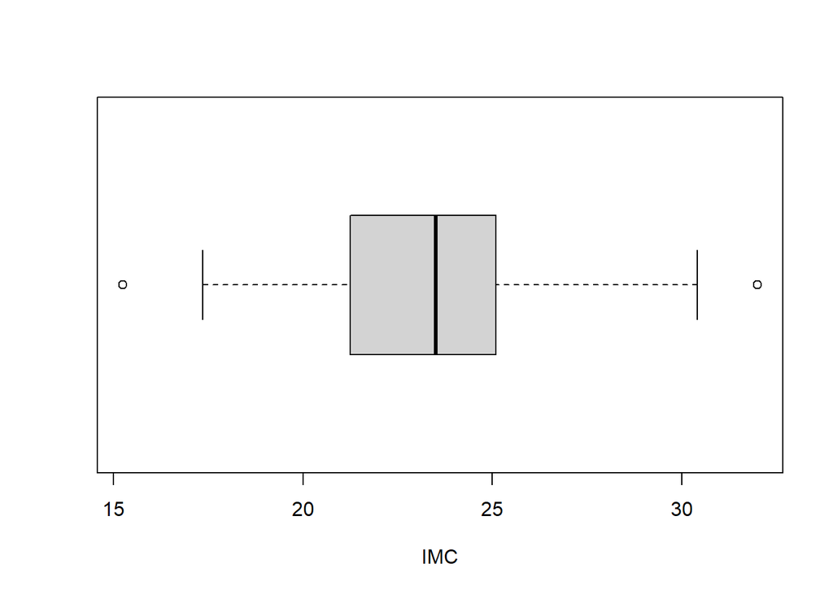

| IMC | Nivel de peso |
| --- | --- |
| menos de 18.5 | Bajo de peso |
| 18.5 - 24.9 | Normal |
| 25.0 - 29.9 | Sobrepeso |
| 30.0 a más | Obesidad |

```r
boxplot(DF2$IMC,horizontal = TRUE,xlab="IMC")
```

##### Tabla de IMC

|  | fa | fr | fp |
| --- | --- | --- | --- |
| Bajo de peso | 9 | 0.04 | 4 |
| Normal | 139 | 0.69 | 69 |
| Sobrepeso | 51 | 0.25 | 25 |
| Obesidad | 2 | 0.01 | 1 |
| Total | 201 | 1.00 | 100 |

##### Gráfico de barras de IMC

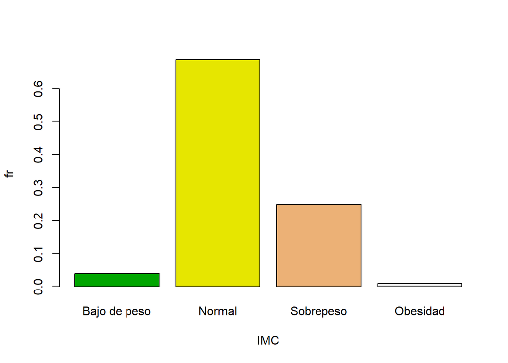

```r
barplot(tablaIMC[1:4,2], col=terrain.colors(4),xlab="IMC", ylab="fr")
```

#### Alimentación balanceada

##### Tabla de alimentación balanceada

```r
tablaAlimentacion<-DF %>% count(AlimentacionBalance)
tablaAlimentacion<-tablaAlimentacion %>% mutate(fr=round(n/(length(DF$`Nombres y Apellidos`)),4))
tablaAlimentacion<-tablaAlimentacion %>% mutate(fp=fr*100)
tablaAlimentacion
```

| AlimentacionBalance | n | fr | fp |
| --- | --- | --- | --- |
| 1 | 8 | 0.0398 | 3.98 |
| 2 | 31 | 0.1542 | 15.42 |
| 3 | 93 | 0.4627 | 46.27 |
| 4 | 54 | 0.2687 | 26.87 |
| 5 | 15 | 0.0746 | 7.46 |

##### Gráfico de barras de alimentación balanceada

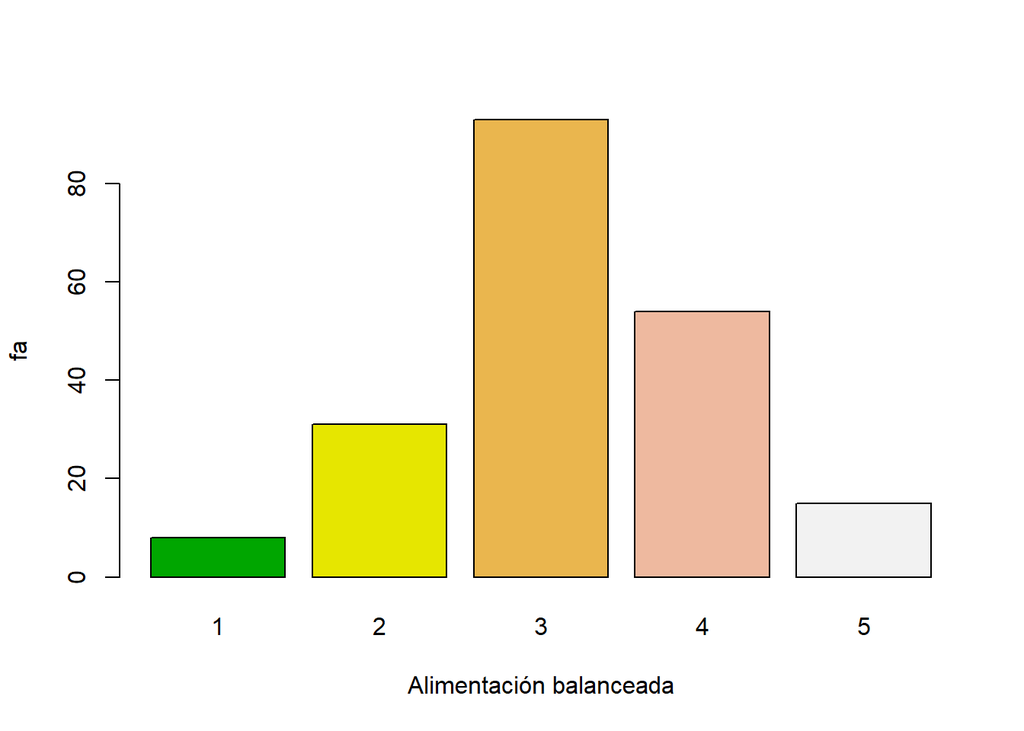

```r
tab.alimentacion<-table(DF$AlimentacionBalance)
barplot(tab.alimentacion,col=terrain.colors(5),xlab="Alimentación balanceada", ylab="fa")
```

#### Horas de sueño

##### Tabla de horas de sueño

```r
tablaSueño<-DF %>% count(HorasZZZ)
tablaSueño<-tablaSueño %>% mutate(fr=round(n/(length(DF$`Nombres y Apellidos`)),4))
tablaSueño<-tablaSueño %>% mutate(fp=fr*100)
tablaSueño
```

| HorasZZZ | n | fr | fp |
| --- | --- | --- | --- |
| 3 | 1 | 0.0050 | 0.50 |
| 4 | 20 | 0.0995 | 9.95 |
| 5 | 23 | 0.1144 | 11.44 |
| 6 | 56 | 0.2786 | 27.86 |
| 7 | 57 | 0.2836 | 28.36 |
| 8 | 43 | 0.2139 | 21.39 |
| 9 | 1 | 0.0050 | 0.50 |

##### Descriptores numéricos de doras de sueño

```r
descpNumericos(DF$HorasZZZ)
```

```
## [1] "Promedio:  6.4"
## [1] "Intervalo de confianza del promedio: [  6.22  :  6.58  ]"
## [1] "desviación estandar:  1.26"
## [1] "Intervalo de confianza de la desviación estandar: [  1.15  :  1.4  ]"
## [1] "Varianza:  1.59"
## [1] "Intervalo de confianza de la varianza: [  1.32  :  1.95  ]"
## [1] "Mediana:  7"
```

```
##    Min. 1st Qu.  Median    Mean 3rd Qu.    Max.
##   3.000   6.000   7.000   6.398   7.000   9.000
```

##### Gráfico de barras de Horas de sueño

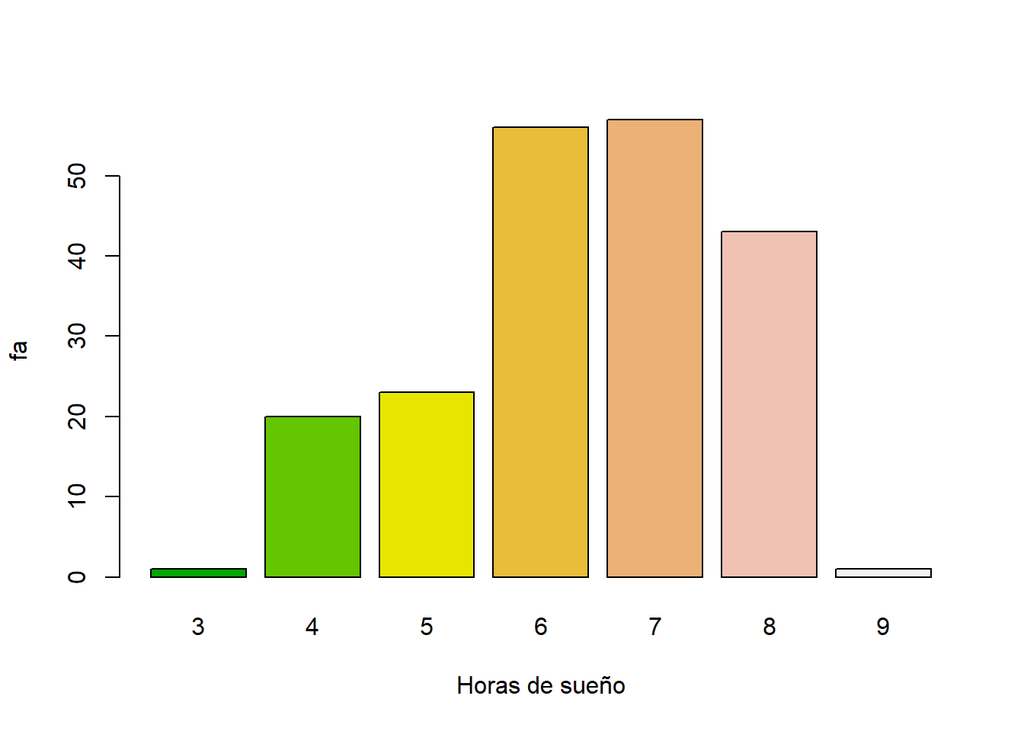

```r
tab.horasSueño<-table(DF$HorasZZZ)
barplot(tab.horasSueño,col=terrain.colors(length(tablaSueño$n)),xlab="Horas de sueño", ylab="fa")
```

#### Horas de actividad física a la semana

##### Tabla de horas de actividad física

```r
tablaEjercicio<-DF %>% count(HorasFisica)
tablaEjercicio<-tablaEjercicio %>% mutate(fr=round(n/(length(DF$`Nombres y Apellidos`)),4))
tablaEjercicio<-tablaEjercicio %>% mutate(fp=fr*100)
tablaEjercicio
```

| HorasFisica | n | fr | fp |
| --- | --- | --- | --- |
| 0 | 42 | 0.2090 | 20.90 |
| 1 | 52 | 0.2587 | 25.87 |
| 2 | 34 | 0.1692 | 16.92 |
| 3 | 22 | 0.1095 | 10.95 |
| 4 | 15 | 0.0746 | 7.46 |
| 5 | 16 | 0.0796 | 7.96 |
| 6 | 8 | 0.0398 | 3.98 |
| 7 | 5 | 0.0249 | 2.49 |
| 8 | 4 | 0.0199 | 1.99 |
| 10 | 1 | 0.0050 | 0.50 |

[output cut: 1 more lines]

##### Descriptores numéricos de horas de actividad física

```r
descpNumericos(DF2$HorasFisica)
```

```
## [1] "Promedio:  2.36"
## [1] "Intervalo de confianza del promedio: [  2.04  :  2.68  ]"
## [1] "desviación estandar:  2.32"
## [1] "Intervalo de confianza de la desviación estandar: [  2.11  :  2.57  ]"
## [1] "Varianza:  5.38"
## [1] "Intervalo de confianza de la varianza: [  4.47  :  6.62  ]"
## [1] "Mediana:  2"
```

```
##    Min. 1st Qu.  Median    Mean 3rd Qu.    Max.
##   0.000   1.000   2.000   2.363   4.000  12.000
```

##### Gráfico de barras de actividad física

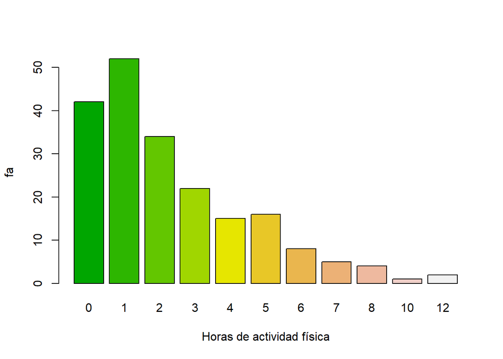

```r
tab.horasEjercicio<-table(DF$HorasFisica)
gb<-barplot(tab.horasEjercicio,col=terrain.colors(length(tablaEjercicio$n)),xlab="Horas de actividad física", ylab="fa")
```

#### Sí posee alguna enfermedad

##### Tabla de enfermedad

```r
tablaSalud<-DF %>% count(Enfermedad)
tablaSalud<-tablaSalud %>% mutate(fr=round(n/(length(DF$`Nombres y Apellidos`)),4))
tablaSalud<-tablaSalud %>% mutate(fp=fr*100)
tablaSalud
```

| Enfermedad | n | fr | fp |
| --- | --- | --- | --- |
| No | 186 | 0.9254 | 92.54 |
| Sí | 15 | 0.0746 | 7.46 |

##### Gráfico circular de enfermedad

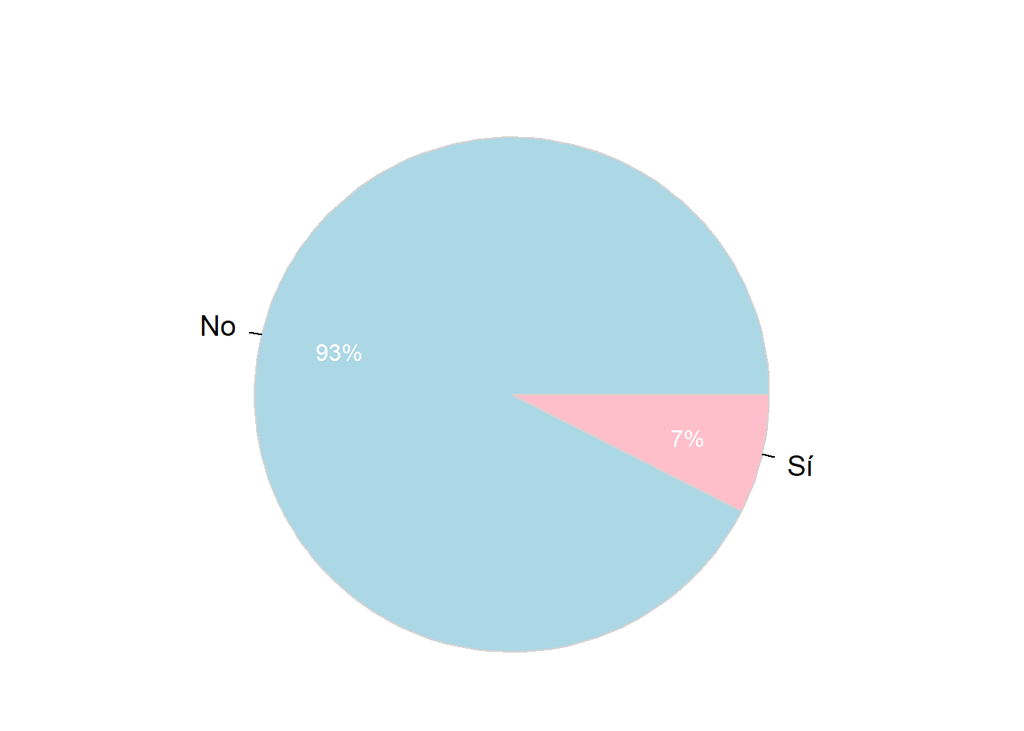

```
## >>> Suggestions
## PieChart(X.DF.Enfermedad., hole=0)  # traditional pie chart
## PieChart(X.DF.Enfermedad., values="%")  # display %'s on the chart
## BarChart(X.DF.Enfermedad.)  # bar chart
## Plot(X.DF.Enfermedad.)  # bubble plot
## Plot(X.DF.Enfermedad., values="count")  # lollipop plot
##
##
## --- X.DF.Enfermedad. ---
##
##
##                   No     Sí     Total
## Frequencies:     186     15       201
## Proportions:   0.925  0.075     1.000
##
##
## Chi-squared test of null hypothesis of equal probabilities
##   Chisq = 145.478, df = 1, p-value = 0.000
```

```r
tab2.salud<-data.frame((DF$Enfermedad))

PieChart(X.DF.Enfermedad., hole = 0, values = "%", data = tab2.salud,
         fill = c("lightblue", "pink"), main = "")
```

#### Enfermedades

##### Tabla enfermedades

```r
tablaen<-DF %>% count(QueEnfermedad)

tablaEnfermedades<-tablaen[complete.cases(tablaen),]
tablaEnfermedades<-tablaEnfermedades %>% mutate(fr=round(n/(length(tablaEnfermedades$n)),4))
tablaEnfermedades<-tablaEnfermedades %>% mutate(fp=fr*100)
tablaEnfermedades
```

| QueEnfermedad | n | fr | fp |
| --- | --- | --- | --- |
| - | 1 | 0.125 | 12.5 |
| Anemia | 1 | 0.125 | 12.5 |
| Asma | 7 | 0.875 | 87.5 |
| Gastritis | 3 | 0.375 | 37.5 |
| Luxación ATM | 1 | 0.125 | 12.5 |
| Miopía | 1 | 0.125 | 12.5 |
| Rinitis crónica | 1 | 0.125 | 12.5 |
| Urticaria | 1 | 0.125 | 12.5 |

#### Gráfico de barras de enfermedades

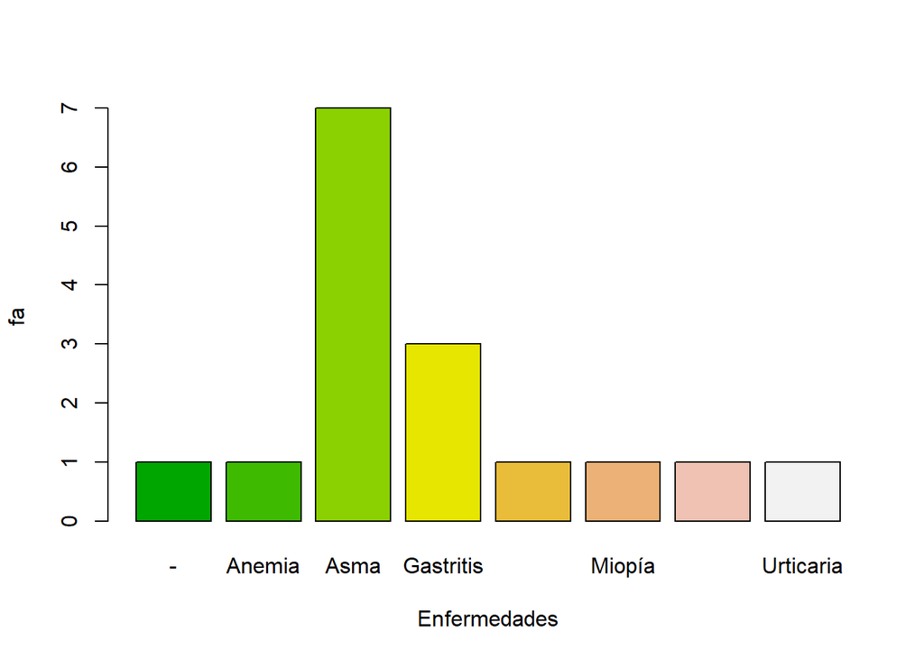

```r
tab.enfermedades<-table(DF$QueEnfermedad)
gb<-barplot(tab.enfermedades,col=terrain.colors(length(tablaEnfermedades$n)),xlab="Enfermedades", ylab="fa")
```

###Variables académicas

#### Promedio de notas

##### Tabla de notas

|  | fa | fr | fp |
| --- | --- | --- | --- |
| [7.8:9.08) | 4 | 0.02 | 2 |
| [9.08:10.36) | 2 | 0.01 | 1 |
| [10.36:11.65) | 11 | 0.05 | 5 |
| [11.65:12.93) | 17 | 0.08 | 8 |
| [12.93:14.21) | 37 | 0.18 | 18 |
| [14.21:15.49) | 45 | 0.22 | 22 |
| [15.49:16.78) | 54 | 0.27 | 27 |
| [16.78:18.06) | 26 | 0.13 | 13 |
| [18.06:19.34) | 5 | 0.02 | 2 |
| Total | 201 | 1.00 | 100 |

##### Descriptores neméricos de notas

```r
descpNumericos(DF$PromedioAnterior)
```

```
## [1] "Promedio:  14.77"
## [1] "Intervalo de confianza del promedio: [  14.48  :  15.06  ]"
## [1] "desviación estandar:  2.07"
## [1] "Intervalo de confianza de la desviación estandar: [  1.89  :  2.29  ]"
## [1] "Varianza:  4.28"
## [1] "Intervalo de confianza de la varianza: [  3.56  :  5.27  ]"
## [1] "Mediana:  15"
```

```
##    Min. 1st Qu.  Median    Mean 3rd Qu.    Max.
##    8.44   13.85   15.00   14.77   16.15   18.70
```

##### Gráfico de pox plot de notas

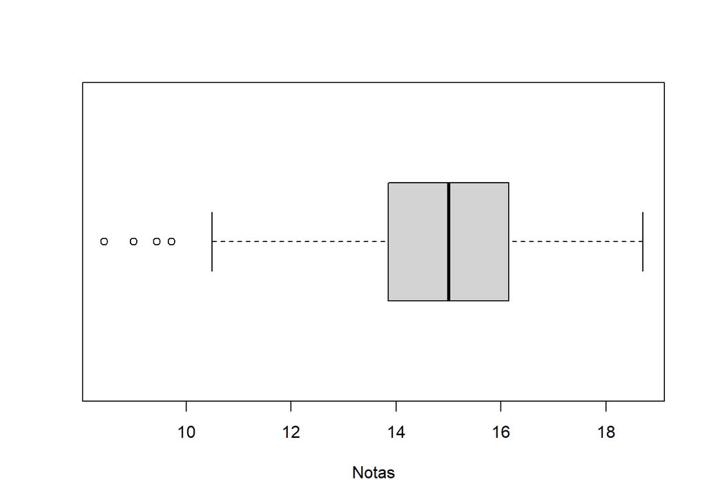

```r
boxplot(DF$PromedioAnterior,horizontal = TRUE,xlab="Notas")
```

##### Histograma de notas

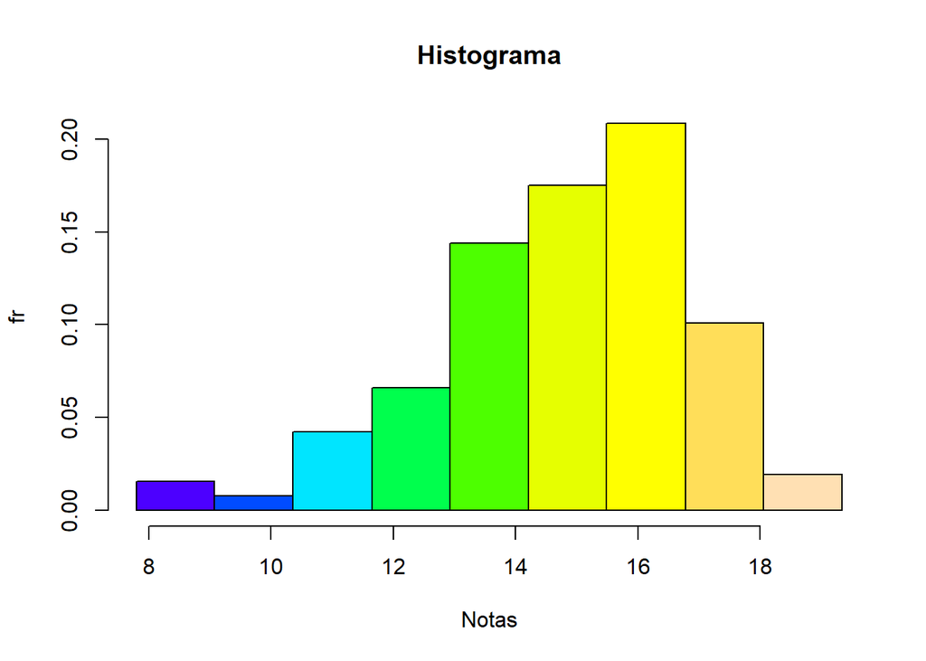

```r
h<-hist(datosNotas,breaksNotas,freq=FALSE, ylab="fr", xlab="Notas", main="Histograma",col=topo.colors(KNotas))
```

#### Satisfación del rendimiento académico

##### Tabla del rendimiento académico

```r
tablaRendimAcademico<-DF %>% count(SatisfaccionResultados)
tablaRendimAcademico<-tablaRendimAcademico %>% mutate(fr=round(n/(length(DF$`Nombres y Apellidos`)),4))
tablaRendimAcademico<-tablaRendimAcademico %>% mutate(fp=fr*100)
tablaRendimAcademico
```

| SatisfaccionResultados | n | fr | fp |
| --- | --- | --- | --- |
| 1 | 24 | 0.1194 | 11.94 |
| 2 | 29 | 0.1443 | 14.43 |
| 3 | 75 | 0.3731 | 37.31 |
| 4 | 62 | 0.3085 | 30.85 |
| 5 | 11 | 0.0547 | 5.47 |

#### Gráfico de barras del rendimiento académico

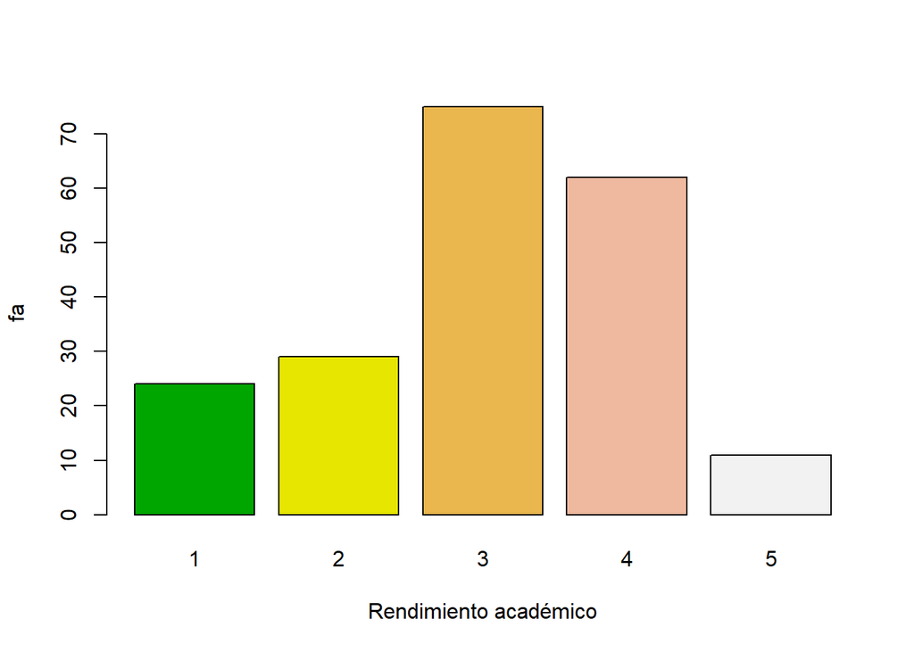

```r
tab.RendimAcademico<-table(DF$SatisfaccionResultados)
gb<-barplot(tab.RendimAcademico,col=terrain.colors(5),xlab="Rendimiento académico", ylab="fa")
```

#### Satisfación con la carrera

##### Tabla de la satisfación con la carrera

```r
tablaSatisCarrera<-DF %>% count(SatisfaccionCarrera)
tablaSatisCarrera<-tablaSatisCarrera %>% mutate(fr=round(n/(length(DF$`Nombres y Apellidos`)),4))
tablaSatisCarrera<-tablaSatisCarrera %>% mutate(fp=fr*100)
tablaSatisCarrera
```

| SatisfaccionCarrera | n | fr | fp |
| --- | --- | --- | --- |
| 1 | 4 | 0.0199 | 1.99 |
| 2 | 15 | 0.0746 | 7.46 |
| 3 | 40 | 0.1990 | 19.90 |
| 4 | 67 | 0.3333 | 33.33 |
| 5 | 75 | 0.3731 | 37.31 |

##### Gráfico de barras de la satisfación con la carrera

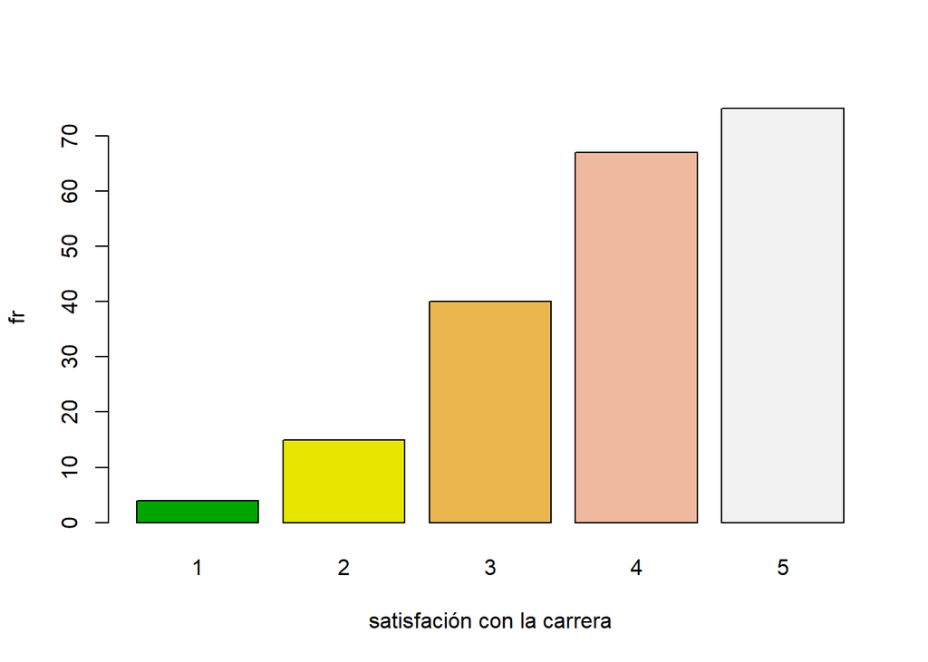

```r
tab.SatisCarrera<-table(DF$SatisfaccionCarrera)
gb<-barplot(tab.SatisCarrera,col=terrain.colors(5),xlab="satisfación con la carrera", ylab="fr")
```

#### Horas de estudio al día

##### Tabla de horas de estudio

```r
tablaEstudio<-DF %>% count(HorasEstudio)
tablaEstudio<-tablaEstudio %>% mutate(fr=round(n/(length(DF$`Nombres y Apellidos`)),4))
tablaEstudio<-tablaEstudio %>% mutate(fp=fr*100)
tablaEstudio
```

| HorasEstudio | n | fr | fp |
| --- | --- | --- | --- |
| 1 | 11 | 0.0547 | 5.47 |
| 2 | 24 | 0.1194 | 11.94 |
| 3 | 27 | 0.1343 | 13.43 |
| 4 | 23 | 0.1144 | 11.44 |
| 5 | 33 | 0.1642 | 16.42 |
| 6 | 23 | 0.1144 | 11.44 |
| 7 | 15 | 0.0746 | 7.46 |
| 8 | 20 | 0.0995 | 9.95 |
| 9 | 7 | 0.0348 | 3.48 |
| 10 | 11 | 0.0547 | 5.47 |

[output cut: 2 more lines]

##### Descriptores numéricos de horas de estudio

```r
descpNumericos(DF2$HorasEstudio)
```

```
## [1] "Promedio:  5.25"
## [1] "Intervalo de confianza del promedio: [  4.87  :  5.63  ]"
## [1] "desviación estandar:  2.72"
## [1] "Intervalo de confianza de la desviación estandar: [  2.48  :  3.02  ]"
## [1] "Varianza:  7.4"
## [1] "Intervalo de confianza de la varianza: [  6.14  :  9.09  ]"
## [1] "Mediana:  5"
```

```
##    Min. 1st Qu.  Median    Mean 3rd Qu.    Max.
##   1.000   3.000   5.000   5.249   7.000  12.000
```

##### Gráfico de barras de estudio

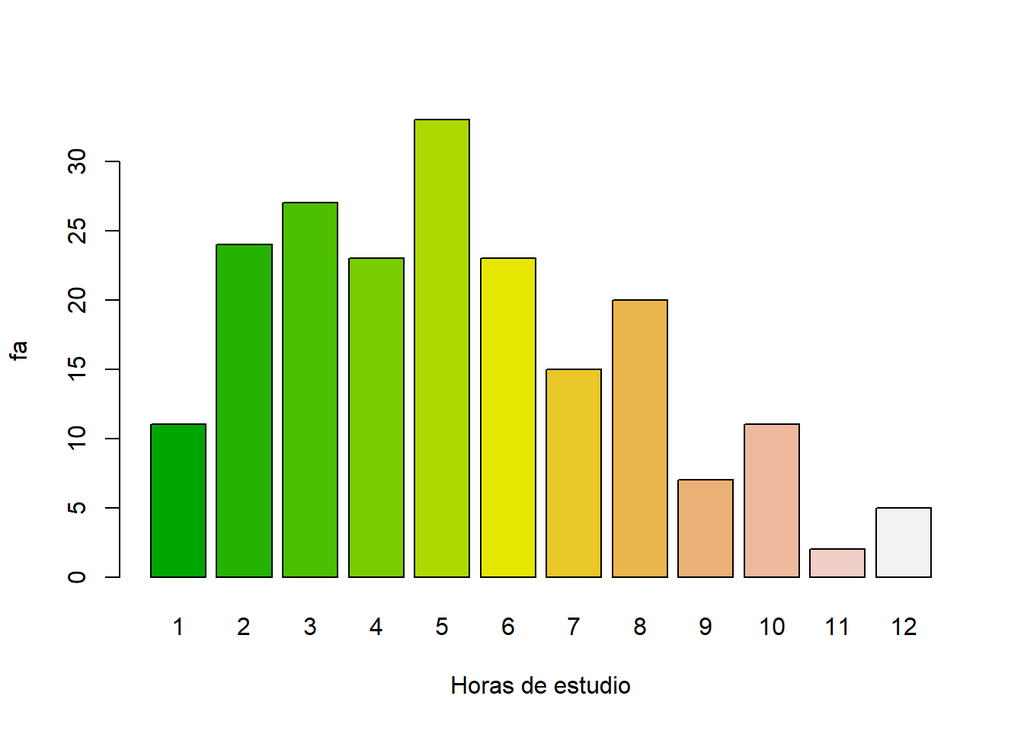

```r
tab.horasEstudio<-table(DF$HorasEstudio)
gb<-barplot(tab.horasEstudio,col=terrain.colors(12),xlab="Horas de estudio", ylab="fa")
```

#### Horas de distracción al día

##### Tabla de horas de distracción

```r
tablaDistraccion<-DF %>% count(HorasDistraccion)
tablaDistraccion<-tablaDistraccion %>% mutate(fr=round(n/(length(DF$`Nombres y Apellidos`)),4))
tablaDistraccion<-tablaDistraccion %>% mutate(fp=fr*100)
tablaDistraccion
```

| HorasDistraccion | n | fr | fp |
| --- | --- | --- | --- |
| 0 | 1 | 0.0050 | 0.50 |
| 1 | 21 | 0.1045 | 10.45 |
| 2 | 60 | 0.2985 | 29.85 |
| 3 | 27 | 0.1343 | 13.43 |
| 4 | 33 | 0.1642 | 16.42 |
| 5 | 25 | 0.1244 | 12.44 |
| 6 | 19 | 0.0945 | 9.45 |
| 7 | 7 | 0.0348 | 3.48 |
| 8 | 4 | 0.0199 | 1.99 |
| 10 | 3 | 0.0149 | 1.49 |

[output cut: 1 more lines]

##### Descriptores numéricos de horas de distracción

```r
descpNumericos(DF2$HorasDistraccion)
```

```
## [1] "Promedio:  3.56"
## [1] "Intervalo de confianza del promedio: [  3.28  :  3.84  ]"
## [1] "desviación estandar:  2.04"
## [1] "Intervalo de confianza de la desviación estandar: [  1.86  :  2.26  ]"
## [1] "Varianza:  4.16"
## [1] "Intervalo de confianza de la varianza: [  3.45  :  5.11  ]"
## [1] "Mediana:  3"
```

```
##    Min. 1st Qu.  Median    Mean 3rd Qu.    Max.
##   0.000   2.000   3.000   3.562   5.000  12.000
```

##### Gráfico de barras de Horas de distracción

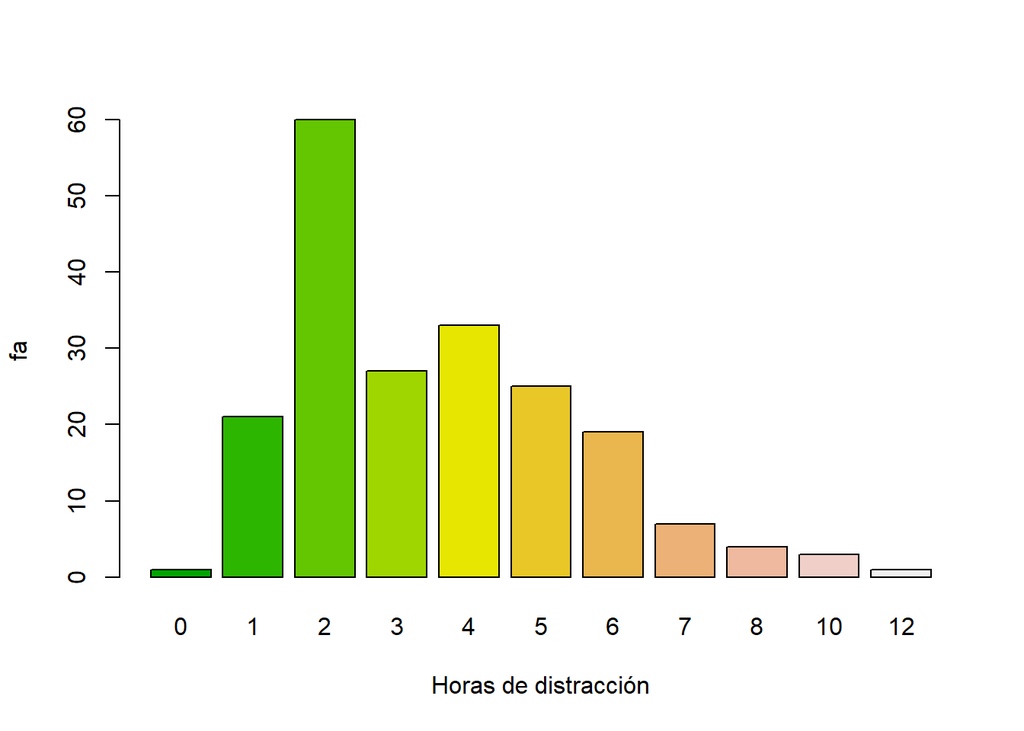

```r
tab.horasDistraccion<-table(DF$HorasDistraccion)
gb<-barplot(tab.horasDistraccion,col=terrain.colors(11),xlab="Horas de distracción", ylab="fa")
```

#### Cursos desaprobados

##### Tabla de Cursos desaprobados

```r
tablaCursosDesaprobados<- DF %>% count(CursosDesaprobados)
tablaCursosDesaprobados<-tablaCursosDesaprobados %>% mutate(fr=round(n/(length(DF$`Nombres y Apellidos`)),4))
tablaCursosDesaprobados<-tablaCursosDesaprobados %>% mutate(fp=fr*100)
tablaCursosDesaprobados
```

| CursosDesaprobados | n | fr | fp |
| --- | --- | --- | --- |
| 0 | 110 | 0.5473 | 54.73 |
| 1 | 48 | 0.2388 | 23.88 |
| 2 | 20 | 0.0995 | 9.95 |
| 3 | 15 | 0.0746 | 7.46 |
| 4 | 7 | 0.0348 | 3.48 |
| 6 | 1 | 0.0050 | 0.50 |

##### Gráfico de barras de Cursos desaprobados

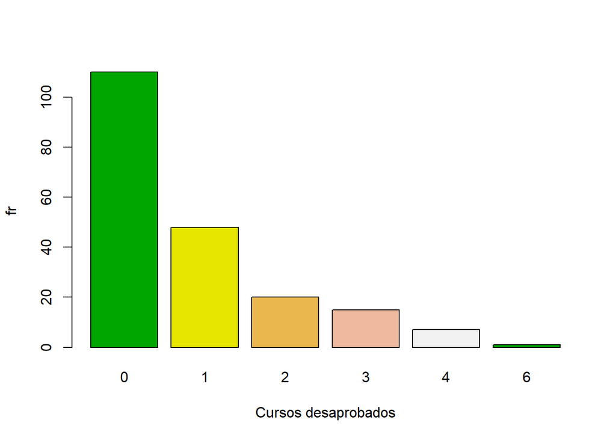

```r
tab.CursosDesaprobados<-table(DF$CursosDesaprobados)
gb<-barplot(tab.CursosDesaprobados,col=terrain.colors(5),xlab="Cursos desaprobados", ylab="fr")
```

#### Cursos llevados por 3ra vez

##### Tabla de Cursos llevados por 3ra vez

```r
tablaCursos3arVez<- DF %>% count(CursosMatric3era)
tablaCursos3arVez<-tablaCursos3arVez %>% mutate(fr=round(n/(length(DF$`Nombres y Apellidos`)),4))
tablaCursos3arVez<-tablaCursos3arVez %>% mutate(fp=fr*100)
tablaCursos3arVez
```

| CursosMatric3era | n | fr | fp |
| --- | --- | --- | --- |
| 0 | 172 | 0.8557 | 85.57 |
| 1 | 20 | 0.0995 | 9.95 |
| 2 | 1 | 0.0050 | 0.50 |
| 3 | 3 | 0.0149 | 1.49 |
| 4 | 2 | 0.0100 | 1.00 |
| 7 | 3 | 0.0149 | 1.49 |

##### Gráfico de barras de Cursos llevados por 3ra vez

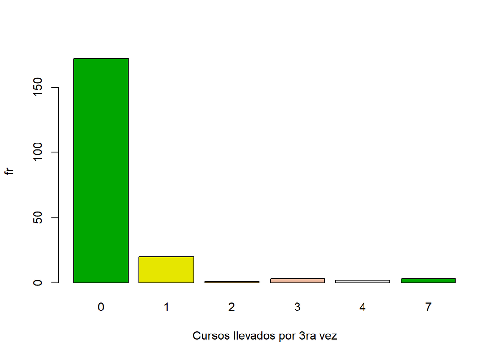

```r
tab.Cursos3arVez<-table(DF$CursosMatric3era)
gb<-barplot(tab.Cursos3arVez,col=terrain.colors(5),xlab="Cursos llevados por 3ra vez", ylab="fr")
```

#### Recursos tecnologicos

##### Tabla de Recursos tecnologicos

```r
tablaRecTec<-DF %>% count(RecursosTecnologicos)
tablaRecTec<-tablaRecTec %>% mutate(fr=round(n/(length(DF$`Nombres y Apellidos`)),4))
tablaRecTec<-tablaRecTec %>% mutate(fp=fr*100)
tablaRecTec
```

| RecursosTecnologicos | n | fr | fp |
| --- | --- | --- | --- |
| Internet, Laptop o PC | 16 | 0.0796 | 7.96 |
| Internet, Laptop o PC, Impresora | 6 | 0.0299 | 2.99 |
| Internet, Laptop o PC, Impresora, Tablet o Ipad | 1 | 0.0050 | 0.50 |
| Internet, Laptop o PC, Tablet o Ipad | 1 | 0.0050 | 0.50 |
| Internet, Laptop o PC, Teléfono | 52 | 0.2587 | 25.87 |
| Internet, Laptop o PC, Teléfono, Impresora | 57 | 0.2836 | 28.36 |
| Internet, Laptop o PC, Teléfono, Impresora, Tablet o Ipad | 50 | 0.2488 | 24.88 |
| Internet, Laptop o PC, Teléfono, Tablet o Ipad | 8 | 0.0398 | 3.98 |
| Internet, Teléfono | 2 | 0.0100 | 1.00 |
| Laptop o PC | 5 | 0.0249 | 2.49 |

[output cut: 3 more lines]

#### Ingreso promedio mensual a la familia

##### Tabla de Ingreso promedio mesual

|  | fa | fr | fp |
| --- | --- | --- | --- |
| [500:3187.5) | 119 | 0.59 | 59 |
| [3187.5:5875) | 44 | 0.22 | 22 |
| [5875:8562.5) | 15 | 0.07 | 7 |
| [8562.5:11250) | 10 | 0.05 | 5 |
| [11250:13937.5) | 3 | 0.01 | 1 |
| [13937.5:16625) | 3 | 0.01 | 1 |
| [16625:19312.5) | 0 | 0.00 | 0 |
| [19312.5:22000) | 6 | 0.03 | 3 |
| [22000:24687.5) | 0 | 0.00 | 0 |
| Total | 201 | 1.00 | 100 |

#### Descriptores númericos de Ingreso promedio mesual

```r
descpNumericos(DF$IngresoPromedioFamiliar)
```

```
## [1] "Promedio:  4135.72"
## [1] "Intervalo de confianza del promedio: [  3567.91  :  4703.53  ]"
## [1] "desviación estandar:  4082.4"
## [1] "Intervalo de confianza de la desviación estandar: [  3718.52  :  4525.84  ]"
## [1] "Varianza:  16665989.76"
## [1] "Intervalo de confianza de la varianza: [  13827375.14  :  20483250.03  ]"
## [1] "Mediana:  3000"
```

```
##    Min. 1st Qu.  Median    Mean 3rd Qu.    Max.
##     500    1750    3000    4136    5000   22000
```

##### Gráfico de pox plot de Ingreso promedio mesual

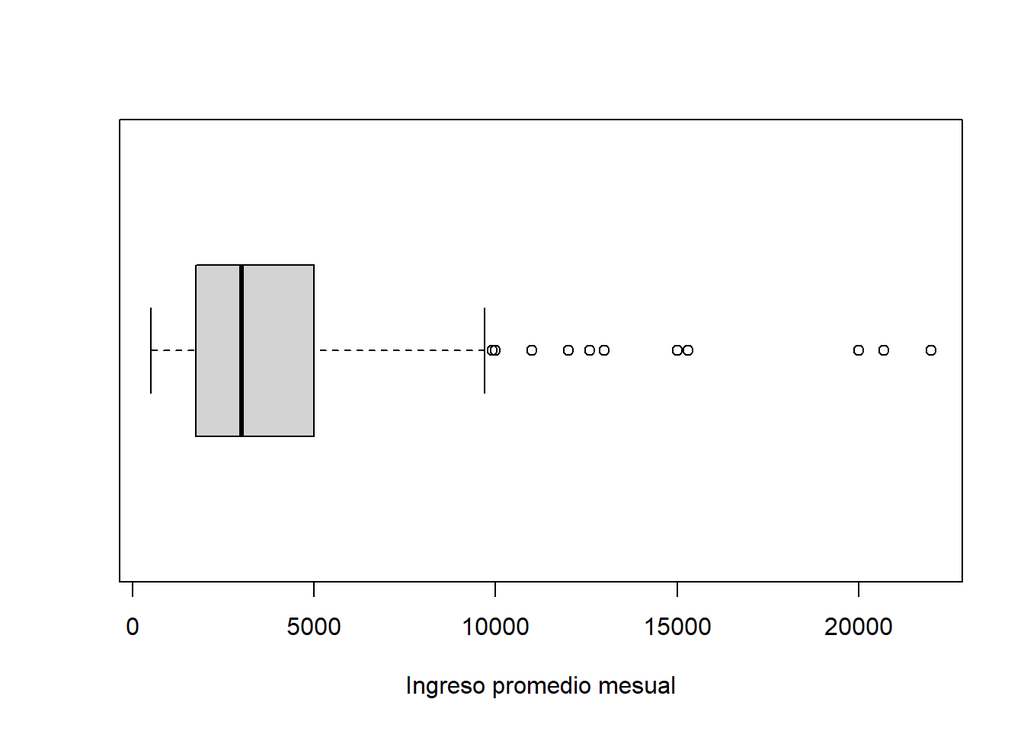

```r
boxplot(DF$IngresoPromedioFamiliar,horizontal = TRUE,xlab="Ingreso promedio mesual")
```

##### Histograma de Ingreso promedio mesual

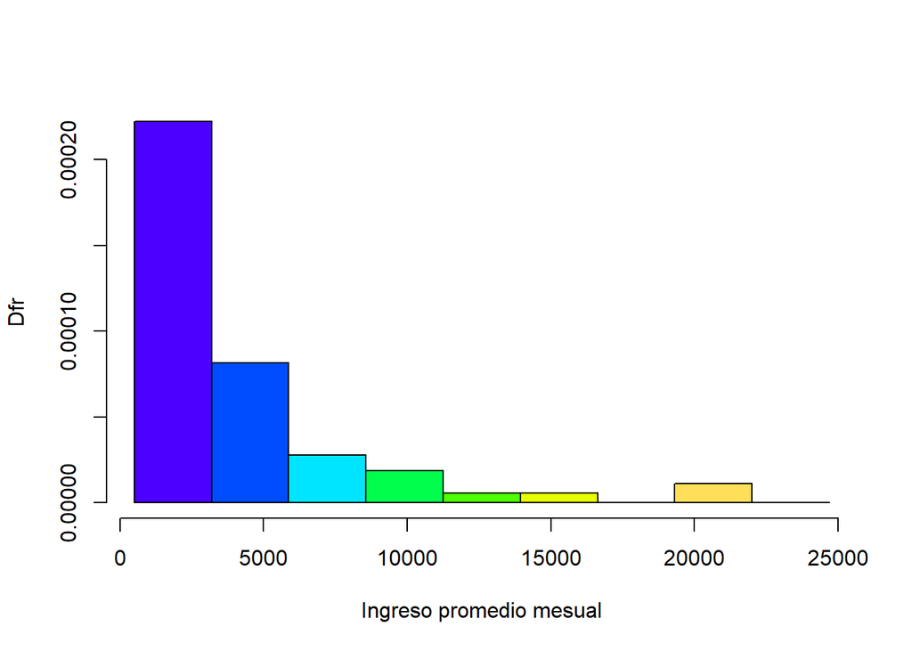

```r
h<-hist(datosIngresoDinero,breaksDinero,freq=FALSE, ylab="Dfr", xlab="Ingreso promedio mesual", main="",col=topo.colors(KDinero))
```

#### Sí estudia y trabaja

##### Tabla

```r
tablaEyT<-DF %>% count(EstudiarTrabajar)
tablaEyT<-tablaEyT %>% mutate(fr=round(n/(length(DF$`Nombres y Apellidos`)),4))
tablaEyT<-tablaEyT %>% mutate(fp=fr*100)
tablaEyT
```

| EstudiarTrabajar | n | fr | fp |
| --- | --- | --- | --- |
| No | 176 | 0.8756 | 87.56 |
| Sí | 25 | 0.1244 | 12.44 |

##### Gráfico circular

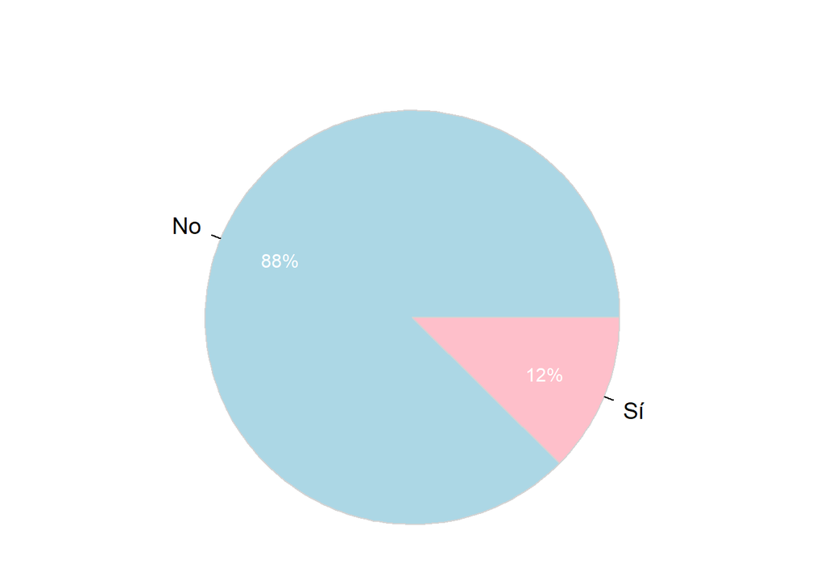

```
## >>> Suggestions
## PieChart(X.DF.EstudiarTrabajar., hole=0)  # traditional pie chart
## PieChart(X.DF.EstudiarTrabajar., values="%")  # display %'s on the chart
## BarChart(X.DF.EstudiarTrabajar.)  # bar chart
## Plot(X.DF.EstudiarTrabajar.)  # bubble plot
## Plot(X.DF.EstudiarTrabajar., values="count")  # lollipop plot
##
##
## --- X.DF.EstudiarTrabajar. ---
##
##
##                   No     Sí     Total
## Frequencies:     176     25       201
## Proportions:   0.876  0.124     1.000
##
##
## Chi-squared test of null hypothesis of equal probabilities
##   Chisq = 113.438, df = 1, p-value = 0.000
```

```r
tab2.EyT<-data.frame((DF$EstudiarTrabajar))

PieChart(X.DF.EstudiarTrabajar., hole = 0, values = "%", data = tab2.EyT,
         fill = c("lightblue", "pink"), main = "")
```

#### Satisfación con las clases en línea

##### Tabla de la satisfación con las clases en línea

```r
tablaClasVirtual<-DF %>% count(SatisfaccionClases)
tablaClasVirtual<-tablaClasVirtual %>% mutate(fr=round(n/(length(DF$`Nombres y Apellidos`)),4))
tablaClasVirtual<-tablaClasVirtual %>% mutate(fp=fr*100)
tablaClasVirtual
```

| SatisfaccionClases | n | fr | fp |
| --- | --- | --- | --- |
| 1 | 10 | 0.0498 | 4.98 |
| 2 | 25 | 0.1244 | 12.44 |
| 3 | 88 | 0.4378 | 43.78 |
| 4 | 64 | 0.3184 | 31.84 |
| 5 | 14 | 0.0697 | 6.97 |

##### Gráfico de barras de la satisfación con las clases en línea

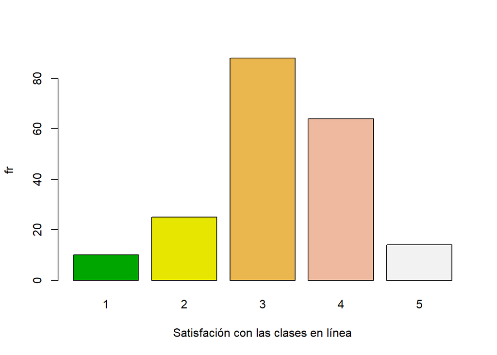

```r
tab.ClasVirtual<-table(DF$SatisfaccionClases)
gb<-barplot(tab.ClasVirtual,col=terrain.colors(5),xlab="Satisfación con las clases en línea", ylab="fr")
```

## Variables aleatorias

**Las siguientes variables cumplen un papel inferencial en el trabajo**

| Variable Aleatoria Discreta | Variable Aleatoria Continua |
| --- | --- |
| Ciclo el cual cursa | Promedio de notas |
| Horas que duerme | Talla |
| Horas a la semana que hace ejercicio | Peso |
| Horas dedicadas al ocio | IMC |
| Cantidad de cursos desaprobados |  |
| Cursos llevados por tercera vez |  |
| Alimentación balanceada |  |
| Satisfacción con la carrera |  |
| Satisfacción con las clases en línea |  |
| Satisfacción con sus notas |  |

### Variables aleatorias discretas

#### Alimentacion balanceada - para el nivel de bienestar de 3

**Distribución binomial**

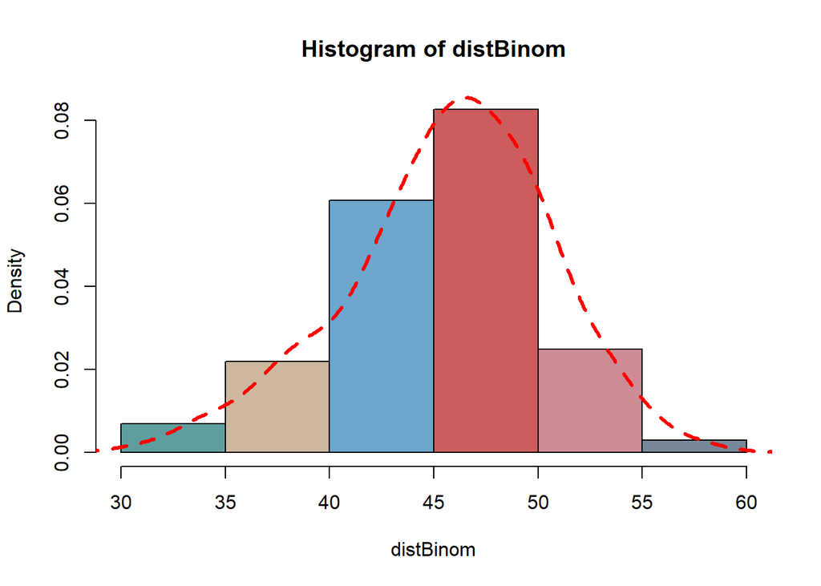

#### Satisfacción con la carrera - satisfacción de 3

**Distribución binomial**

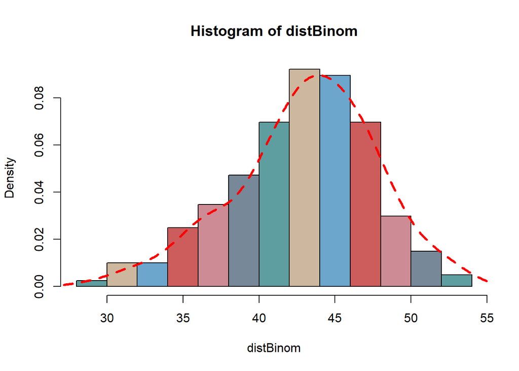

### Variables aleatorias continuas

**Las siguientes variables tienen una distribución normal**

#### Pesos

**Distribución normal**

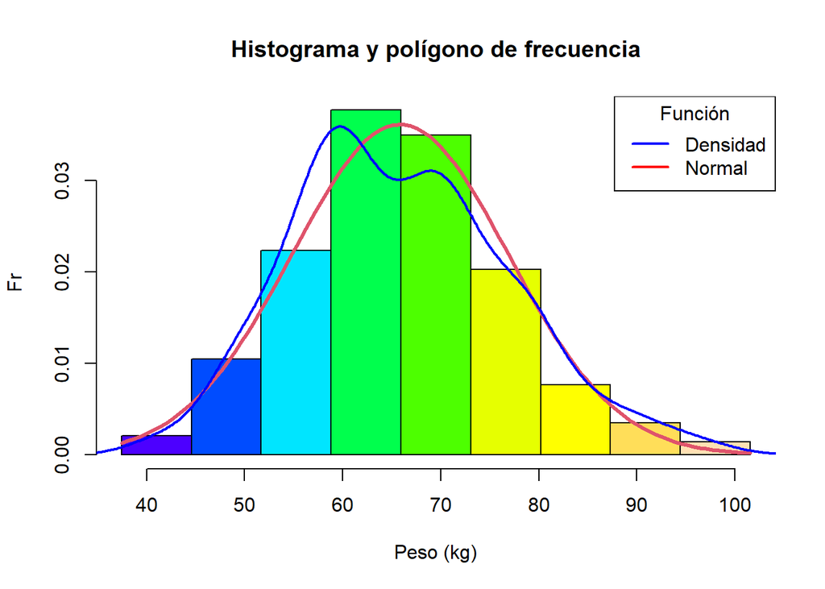

#### Tallas

**Distribución normal**

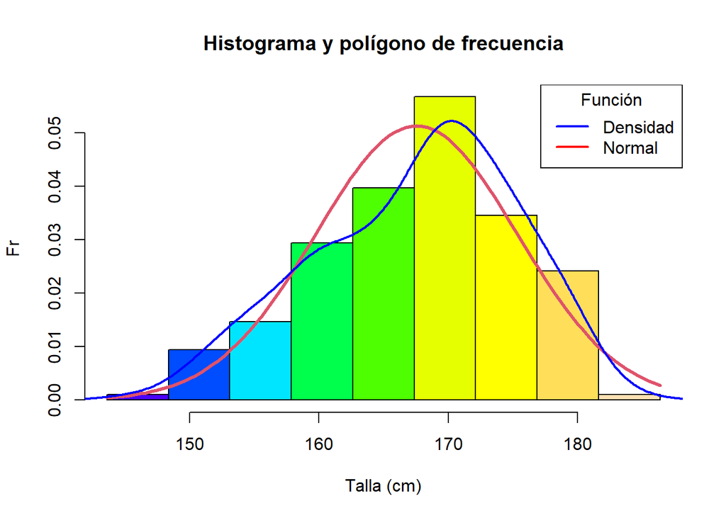